# 12. praktikum

01.04.2026

# Lineaarse regressiooni mudelid 2

## Tänases praktikumis

- Mitme tunnusega lineaarne regressioon
- Tunnuste vahelised interaktsioonid
- Parima mudeli valimine

Andmestikud endiselt:

- `ldt.csv`
- `fonkorp2` (loeme otse DataDOIst, ei pea alla laadima)

## Kaks arvulist tunnust

### Näide 1: Kas lisaks sõna pikkusele võiks reaktsiooniaega mõjutada sõna sagedus?

Loeme sisse `ldt.csv` andmestiku, kust eelmisel korral vaatasime reaktsiooniaja seost sõna pikkusega. See mäletatavasti oli statistiliselt oluline seos, mis kirjeldas umbes 35% reaktsiooniaja varieerumisest.

```r
ldt <- read.csv("data/ldt.csv")
# Jätame alles ainult read, kus Mean_RT < 1200 ms
ldt2 <- ldt[ldt$Mean_RT < 1200,]
```

Nüüd proovime, kas mudel läheb paremaks, kui me lisame sinna seletavaid tunnuseid. Üks sõnade äratundmiseks kuluvat reaktsiooniaega mõjutav tunnus võiks lisaks sõna pikkusele olla sõna sagedus: võiks oletada, sagedasemaid sõnu tunneme me ära kiiremini kui vähemsagedasi.

Enne mudelisse lisamist vaatame selle faktori jaotust.

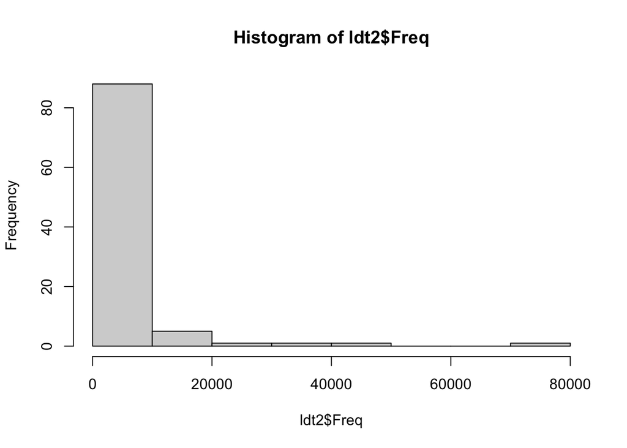

```r
hist(ldt2$Freq)
```

Sagedus on tugevalt paremale kaldu, seda on juba histogrammilt näha. Proovime logaritmida.

Kuna siin on 0-sagedusega sõnu ja logaritm nullist on miinus lõpmatus,

```r
log(0)
```

```
## [1] -Inf
```

siis siin saab kasutada käsku `log1p()`, mis liidab algsele väärtusele ühe ja siis logaritmib, vältides nii -Inf (ehk miinus lõpmatus) väärtuseid.

```r
# Võrdle!
log(1:3); log1p(0:2)
```

```
## [1] 0.0000000 0.6931472 1.0986123
```

```
## [1] 0.0000000 0.6931472 1.0986123
```

Testime normaaljaotust logaritmitud väärtustega:

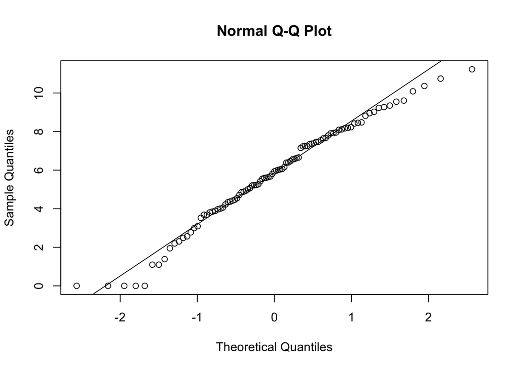

```r
qqnorm(log1p(ldt2$Freq))
qqline(log1p(ldt2$Freq))
```

```r
shapiro.test(log1p(ldt2$Freq))
```

```
##
##  Shapiro-Wilk normality test
##
## data:  log1p(ldt2$Freq)
## W = 0.9794, p-value = 0.1313
```

Logaritmimine aitas, nüüd on tunnus normaalajotusega.

Läheme edasi mudeliga. Mudelis lisatakse sõltumatud tunnused +-märgiga. Kui enne ühe seletava tunnusega mudeli valem oli y ~ x, siis nüüd on see y ~ x1 + x2.

```r
ldt2.mod1 <- lm(Mean_RT ~ Length + log1p(Freq),
               data = ldt2)
```

## Kuidas mudelit lugeda?

```r
summary(ldt2.mod1)
```

```
##
## Call:
## lm(formula = Mean_RT ~ Length + log1p(Freq), data = ldt2)
##
## Residuals:
##      Min       1Q   Median       3Q      Max
## -219.823  -58.871   -2.198   44.140  243.543
##
## Coefficients:
##             Estimate Std. Error t value Pr(>|t|)
## (Intercept)  762.232     50.251  15.168  < 2e-16 ***
## Length        18.895      4.265   4.430 2.54e-05 ***
## log1p(Freq)  -21.348      3.894  -5.483 3.51e-07 ***
## ---
## Signif. codes:  0 '***' 0.001 '**' 0.01 '*' 0.05 '.' 0.1 ' ' 1
##
## Residual standard error: 87.47 on 94 degrees of freedom
## Multiple R-squared:  0.5048, Adjusted R-squared:  0.4943
## F-statistic: 47.91 on 2 and 94 DF,  p-value: 4.509e-15
```

- Samamoodi nagu ühe seletava tunnusega mudeli puhul, tuleks vaadata kõigepealt väljundi viimast rida, et kas **mudel üldiselt on oluline**. See mudel on, p<0.001.
- Teiseks tuleks vaadata eelviimast rida, **R-ruutu**. See mudel seletab 50% reaktsiooniaja varieerumisest, seega on see päris hea mudel ja faktori lisamine tegi asja paremaks, sest ainult sõna pikkust arvestav mudel, mida testisime eelmises praktikumis, seletas 35%. Mudelite võrdlemisest tuleb natuke põhjalikumalt juttu peagi.

Vaatame nüüd **koefitsientide tabelit** (*Coefficients*).

- Siin mudelis on kahe faktori **üldefektid**. Need mõjuvad uuritavale tunnusele üksteisest sõltumata. **Vabaliikme** väärtus on endiselt **reaktsiooniaeg juhul, kui kõigi seletavate tunnuste väärtus on 0**. Iga seletava tunnuse efekt on uuritava tunnuse väärtuse muutus siis, kui see **seletav tunnus kasvab ühe ühiku võrra**.
- Kui seletava tunnuse efekt on negatiivne, siis seos on vastupidine: seletav tunnus kasvab ja uuritav kahaneb.
- Mudeli võime kirja panna valemina  
  **Reaktsiooniaeg = 762 + 19 * sõna pikkus - 21 * log1p(sõna sagedus)**
- Kuna *sagedus* on mudelis logaritmitud, siis seda peame ka mudeli prognooside arvutamisel arvestama. Selle kordajaga peaks korrutama logaritmitud sagedusi.

Me võime mudelit testida, arvutades välja prognoosi seletavate tunnuste keskmiste väärtuste korral ning võrrelda seda reaalse andmestiku keskmisega. Tegelikud keskmised väärtused on:

```r
apply(ldt2[,-1], 2, mean)
```

```
##      Length        Freq     Mean_RT
##    8.092784 3452.103093  792.117938
```

paneme need valemisse  
**RT = 762 + 19 * pikkus - 21 * log1p(sagedus)**

```r
762.232 + 18.895 * 8.09 + -21.348 * log1p(3452.10)
```

```
## [1] 741.1698
```

Mudeli prognoose võime muidugi ka otse mudelist lugeda ja valemites rakendada. Vaatame `lm()` käsuga saadud objekti, et saada natuke aimu, mis struktuuriga objekt see on:

```r
str(ldt2.mod1); names(ldt2.mod1$coefficients)
```

Käsk `str()` aitab ehk kõige paremini lm() objekti lahti muukida: tegemist on listilaadse objektiga, kus element “coefficients” on vektor mudeli prognooside väärtustega. Kasutame nüüd neid koefitsentide väärtusi, et arvutada mudeliprognoose. Nii saame arvutada, mis võiks olla reaktsiooniaeg keskmise pikkusega keskmise sagedusega sõna korral:

```r
ldt2.mod1$coefficients["(Intercept)"] +
  mean(ldt2$Length) * ldt2.mod1$coefficients["Length"] +
  log1p(mean(ldt2$Freq)) * ldt2.mod1$coefficients["log1p(Freq)"]
```

```
## (Intercept)
##    741.2168
```

Joonistame mudeli põhjal regressioonijooned nii, et teise tunnuse väärtus oleks keskmine, mitte 0.

Sõna sagedust joonistades peame arvestama sellega, et mudelis on see logaritmitud ja regressioonijoont arvestades peame seda ka lograitmima, aga siis ei ole skaala ühikust kerge aru saada. Siin joonisel on see lahendatud nii, et punktid ja jooned on joonistatud logaritmitud väärtustega ning joonise x-teljele on lisatud skaala, kus väärtused on uuesti astendatud.

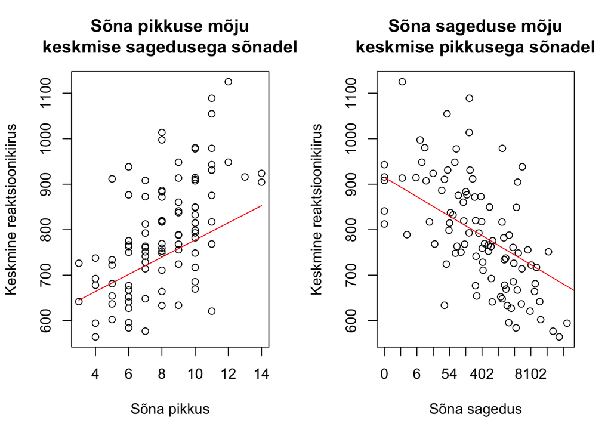

```r
par(mfcol = c(1,2)) # Kuva järgmised joonised ühes reas, kahes tulbas
plot(Mean_RT ~ Length, data = ldt2,
     xlab = "Sõna pikkus", ylab = "Keskmine reaktsioonikiirus",
     main = "Sõna pikkuse mõju\nkeskmise sagedusega sõnadel")
lines(x = 3:14,
      y = (ldt2.mod1$coefficients["(Intercept)"] +
               3:14 * ldt2.mod1$coefficients["Length"] +
               log1p(mean(ldt2$Freq)) * ldt2.mod1$coefficients["log1p(Freq)"]),
      col = "red")

plot(Mean_RT ~ log1p(Freq), data = ldt2,
     xlab = "Sõna sagedus", ylab = "Keskmine reaktsioonikiirus",
     main = "Sõna sageduse mõju\nkeskmise pikkusega sõnadel",
     axes=F)
lines(x = 0:12,
      y = (ldt2.mod1$coefficients["(Intercept)"] +
               mean(ldt2$Length) * ldt2.mod1$coefficients["Length"] +
               0:12 * ldt2.mod1$coefficients["log1p(Freq)"]),
      col = "red")
# Samuti arvestame sellega, et sagedus oli logaritmitud, aga joonisel tahaks päris väärtusi näha.
box(); axis(side = 2); axis(side = 1, at = 0:12, labels = round(exp(0:12)-1))
```

```r
par(mfcol = c(1, 1))
```

Sama ggplotiga:

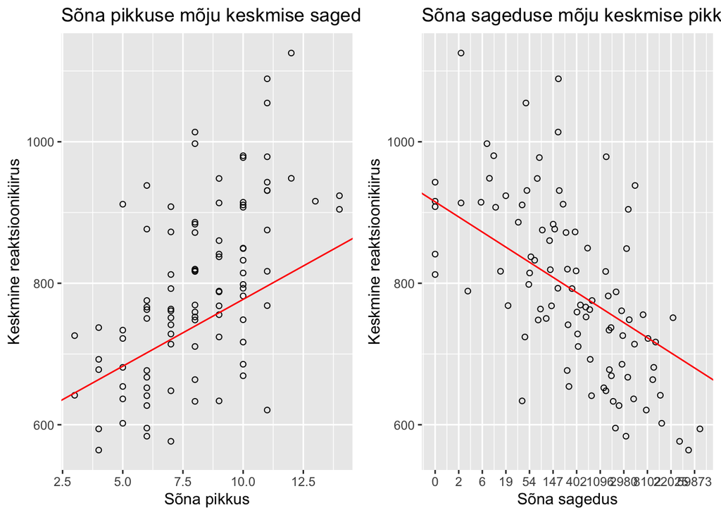

```r
library(ggplot2)
library(gridExtra) # pakett, millega saab erinevaid jooniseid paneelidena ühe joonise peale kokku panna
paneel1 <- ggplot(data = ldt2, aes(x = Length, y = Mean_RT)) +
    geom_point(shape = 1) +
    geom_abline(intercept = ldt2.mod1$coefficients["(Intercept)"] +
                    log1p(mean(ldt2$Freq)) * ldt2.mod1$coefficients["log1p(Freq)"],
                slope = ldt2.mod1$coefficients["Length"],
                color = "red") +
    labs(x = "Sõna pikkus", y = "Keskmine reaktsioonikiirus",
         title = "Sõna pikkuse mõju keskmise sagedusega sõnadel")


paneel2 <- ggplot(data = ldt2, aes(x = log1p(Freq), y = Mean_RT)) +
    geom_point(shape = 1) +
    geom_abline(intercept = ldt2.mod1$coefficients["(Intercept)"] +
                    mean(ldt2$Length) * ldt2.mod1$coefficients["Length"],
                slope = ldt2.mod1$coefficients["log1p(Freq)"],
                color = "red") +
    scale_x_continuous(breaks = seq(0,12,1),
                       labels = round(exp(seq(0,12,1)))-1) + # Kuva tavalised sagedused
    labs(x = "Sõna sagedus", y = "Keskmine reaktsioonikiirus",
         title = "Sõna sageduse mõju keskmise pikkusega sõnadel")
grid.arrange(paneel1, paneel2, ncol=2)
```

Kui tahame sageduse skaalat joonisele lineaarsena (st x-telje intervallid on ühesuurused), siis tuleb regressioonijoon joonistada kõverana.

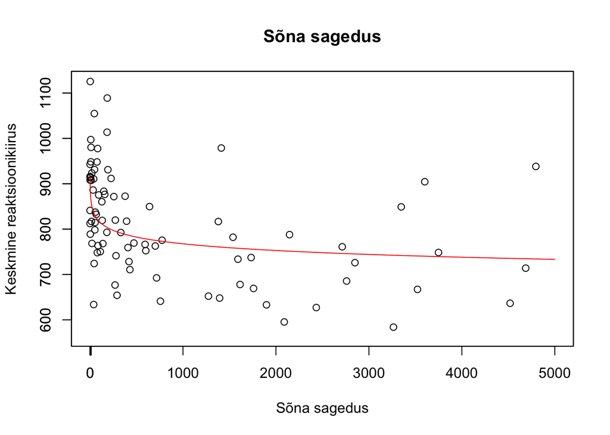

```r
plot(Mean_RT  ~Freq, data = ldt2,
     xlab="Sõna sagedus", ylab="Keskmine reaktsioonikiirus", main="Sõna sagedus",
     xlim=c(0, 5000))

lines(x = 0:5000, y = (ldt2.mod1$coefficients["(Intercept)"] +
                           mean(ldt2$Length) * ldt2.mod1$coefficients["Length"] +
                           log1p(0:5000) * ldt2.mod1$coefficients["log1p(Freq)"]),
      col="red")
box(); axis(side=2); axis(side=1, at=0:12, labels = round(exp(0:12)-1))
```

## Veel mudeli efektide visualiseerimisest

Mudeleid saab visualiseerida ka ggploti laiendavate pakettide abil.

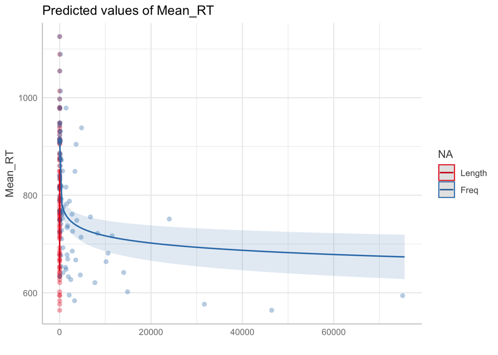

```r
# install.packages("ggeffects")
library(ggeffects)
 plot(ggpredict(model = ldt2.mod1), facets = T, show_data = T) + labs(x = "")
```

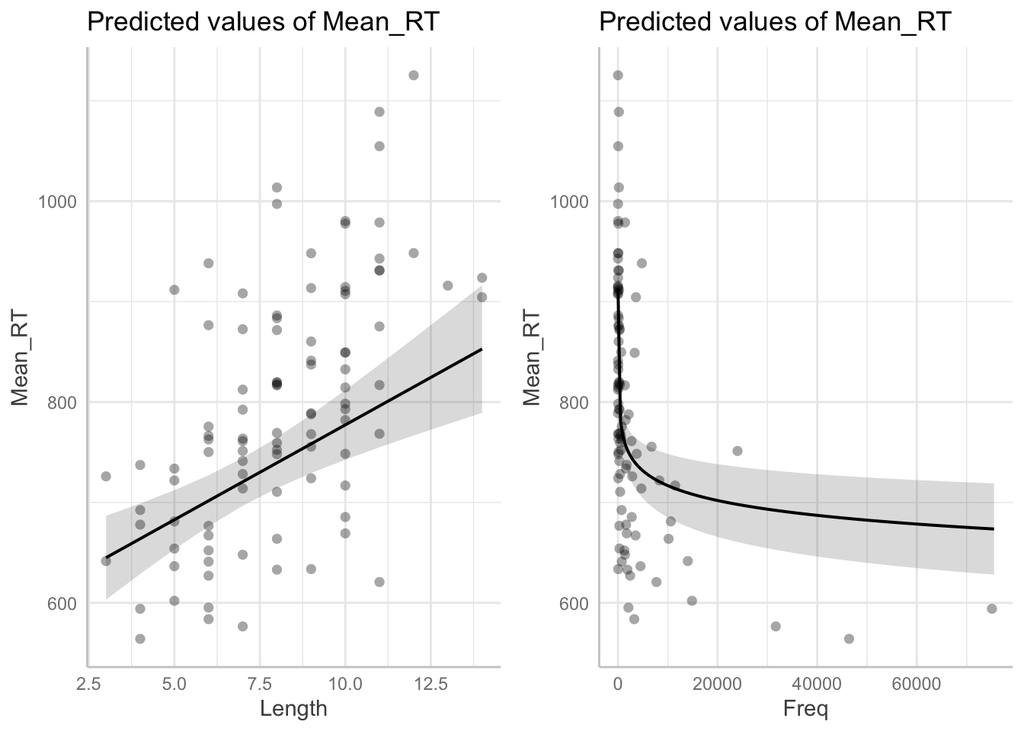

```r
 # efektid eraldi paneelidele
paneel1 = plot(ggpredict(model = ldt2.mod1), show_data = T)$Length
paneel2 = plot(ggpredict(model = ldt2.mod1), show_data = T)$Freq
grid.arrange(paneel1, paneel2, ncol=2)
```

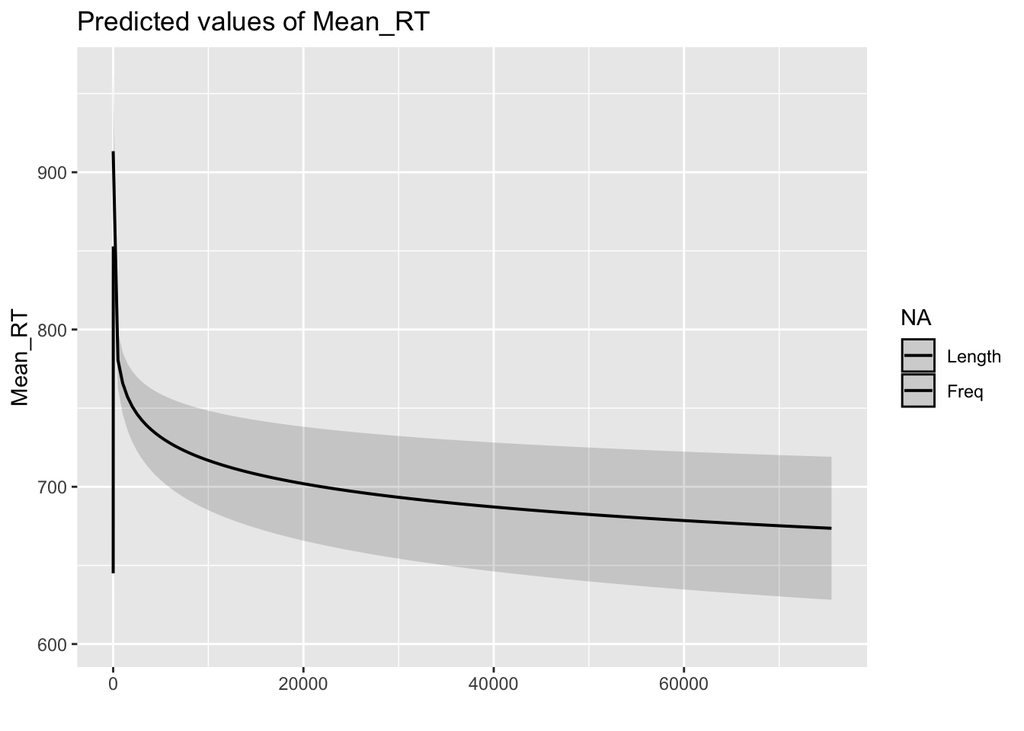

```r
# install.packages("sjPlot")
library(sjPlot)
plot_model(ldt2.mod1, type = "pred", grid = T) + labs(x = "")
```

### Interaktiivsed joonised

Paketiga `plotly` saab ggploti joonised teha interaktiivseks, nii et RStuudios Viewer aknas või RMarkdownist genereeritud html-dokumendis saab joonisel hiirega üle sõites näha punktide väärtuseid ning saab sisse ja välja zoomida:

```r
# install.packages("plotly")
library(plotly)
ggplotly(paneel1)
```

[interactive chart not shown]

Ja kaks paneeli kõrvuti:

```r
subplot(ggplotly(paneel1), ggplotly(paneel2))
```

[interactive chart not shown]

## Peamõju ja interaktsioon

**Peamõju ehk üldefekt** toimib mitme tunnusega mudelis teistest tunnustest sõltumatuna. Näiteks kui reaktsiooniaeg sõltub sõna pikkusest ja sagedusest, nagu viimases näites, siis peaks sõna pikkuse efekt olema alati sama suur sõltumata sõna sagedusest ja sõna sageduse efekt alati sama suur sõltumata sõna pikkusest.

Kuid seletavate tunnuste vahel võib ka esineda **koosmõju ehk interaktsioon**. See tähendab, et ühe tunnuse mõju mõjutab teise tunnuse mõju. Näiteks pikemaid sõnu tuntakse ära aeglasemalt ja sagedasemaid sõnu kiiremini, aga a) pikki sagedasemaid sõnu tuntakse ära sama kiiresti kui lühikesi sagedasi sõnu, või b) lühikesi sagedasi sõnu tuntakse ära eriti kiiresti. Sellisel juhul on lisaks kummagi tunnuse peamõjule ka tunnuste vahel interaktsioon.

Peamõju ja interaktsioon `lm()` funktsioonis:

- Mudeli süntaksis eraldatakse erinevad mõjud plussiga: y ~ x1 + x2
- Interaktsiooni märkimiseks koolon: y ~ x1 + x2 + x1:x2
- Tärniga saab tähistada lühidalt faktorite vahelist peamõju ja interaktsiooni korraga, tulemus on sama, mis eelmisel real: y ~ x1 * x2

Kõik peamõjude kombinatsioonid võivad anda interaktsiooni:

Peamõjusid võib olla ka rohkem kui kaks. Ja sel juhul võvad interaktsioonid olla ka kõikide kombinatsioonide vahel:

- 2 faktorit, 1 kahene interaktsioon: y ~ x1 + x2 + x1:x2
- 3 faktorit, 3 kahest ja üks kolmene interaktsioon: y ~ x1 + x2 + x3 + x1:x2 + x1:x3 + x2:x3 + x1:x2:x3
- 4 faktorit, 6 kahest, 4 kolmest ja 1 neljane interaktsioon:  
  y ~ x1 + x2 + x3 + x4 +  
  x1:x2 + x1:x3 + x1:x4 + x2:x3 + x2:x4 + x3:x4 +  
  x1:x2:x3 + x1:x2:x4 + x1:x3:x4 + x2:x3:x4 +  
  x1:x2:x3:x4
- jne. Mida rohkem faktoreid, seda rohkem kombinatsioone ja seda keerukam mudel.

## Kaks arvulist tunnust interaktsiooniga

### Näide 2: Kas sõna pikkus ja sagedus mõjutavad reaktsiooniaega?

Kui enne vaatasime ainult peamõjudega sõna pikkuse ja sageduse efekti reaktsiooniajale, siis nüüd lisame ka interaktsiooni. R-i `lm()` süntaksis võiks selleks kasutada lihtsalt tärni (*), aga kirjutame siin praegu pikalt välja:

```r
ldt2.mod2 <- lm(Mean_RT ~ Length + log1p(Freq) + Length:log1p(Freq),
               data=ldt2)
summary(ldt2.mod2)
```

```
##
## Call:
## lm(formula = Mean_RT ~ Length + log1p(Freq) + Length:log1p(Freq),
##     data = ldt2)
##
## Residuals:
##      Min       1Q   Median       3Q      Max
## -220.071  -59.205   -0.926   44.653  243.970
##
## Coefficients:
##                    Estimate Std. Error t value Pr(>|t|)
## (Intercept)        771.2282    94.2795   8.180 1.42e-12 ***
## Length              17.8945     9.8342   1.820   0.0720 .
## log1p(Freq)        -22.6969    12.5576  -1.807   0.0739 .
## Length:log1p(Freq)   0.1575     1.3934   0.113   0.9103
## ---
## Signif. codes:  0 '***' 0.001 '**' 0.01 '*' 0.05 '.' 0.1 ' ' 1
##
## Residual standard error: 87.93 on 93 degrees of freedom
## Multiple R-squared:  0.5049, Adjusted R-squared:  0.4889
## F-statistic: 31.61 on 3 and 93 DF,  p-value: 3.545e-14
```

Mudeli väljundisse lisandub rida Length:log1p(Freq). Antud juhul see interaktsiooni efekt ei ole oluline, p on suurem kui 0.05.

### Kuidas interaktsioone tõlgendada?

Kuigi siin näites ei osutunud interaktsioon oluliseks, siis selle mudeli põhjal peaks reaktsiooni aja prognoose arvutama nii:  
**RT = 771 + 18*pikkus + -23*sagedus + 0.16*pikkus*sagedus**  
Ja see tähendaks, et reaktsiooniaeg on:

1. pikem pikemate sõnadega (kasvab 18 ms sõna igatähemärgi kohta),
2. lühem sagedate sõnadega (kahaneb 23 ms logaritmitud sagedusühiku kohta), aga
3. natuke pikem *pikkade sagedate* sõnadega (täiendavalt pikeneb 0.16 ms iga pikkuse ja sageduse ühiku kohta).

**Peamõjud ilma interaktsioonita:**

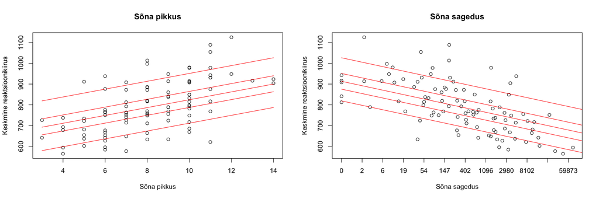

Kui faktorite vahel ei ole interaktsioone, siis on ühe tunnuse regressioonijooned teise tunnuse erinevate tasemete puhul paralleelsed.

**Peamõjud interaktsiooniga**

Kuna interaktsioon mudelis `ldt2.mod2` ei olnud oluline, siis selleks et interaktsiooni efekti illustreerida, toome paar **fiktiivset** näidet: Esiteks oletame, et pikkuse ja sageduse vahel on positiivne interaktsioon, näiteks:  
**RT = 700 + 15*pikkus + -25*sagedus + 3*pikkus*sagedus**

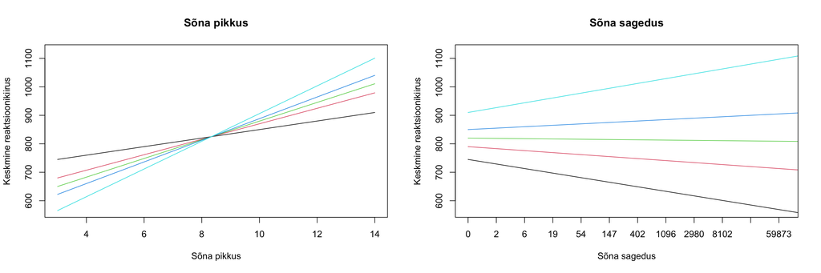

Niisiis, positiivse interaktsiooni mõjul on madala sagedusega sõnadel pikkusel väiksem efekt (must joon vasakul), aga sagedasemate sõnade korral on pikkuse efekt tugevam (järsem kalle, helesinine joon). Sõna sagedusele, mille peaefekt oli negatiivne, mõjub interaktsioon vastupidiselt.

Ja kui interaktsioon oleks negatiivne:  
**RT = 1000 + 15*pikkus + -25*sagedus + -3*pikkus*sagedus**

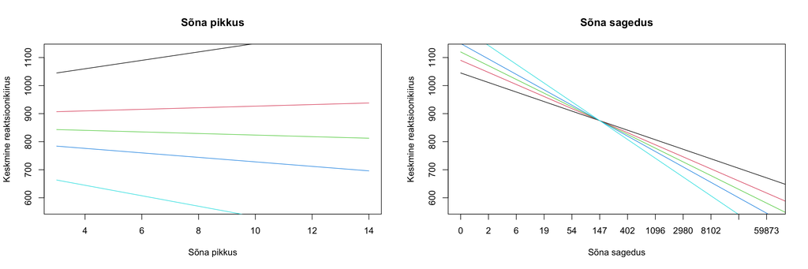

Aga veelkord, need on fiktiivsed näited, mistõttu ei lähe jooned joonistel ka tegelike andmepunktidega päriselt kokku :)

## Mudelite võrdlemine

### Occami habemenoa printsiip

*Occam’s razor* ehk __Occami habemenoa printsiip (https://et.wikipedia.org/wiki/Ockhami_habemenuga)__ ütleb, et parim seletus on kõige lihtsam seletus. Occami habemenoa printsiibile toetudes tuleks alati mudelist välja visata kõik, mis ei ole oluline, et mudel oleks võimalikult lihtne.

Mudelite võrdlemiseks on mitu üksteist täiendavat meetodit: võib lihtsalt vaadata, et ei oleks ebaolulisi tunnuseid mudelis, võib vaadata mudeli seletusvõimet R-ruudu näol, võib võrrelda erinevusi mudeli jääkides või teha spetsiaalselt mudelite headuse võrdlemiseks mõeldud teste (mis üldiselt toetuvad ka mudeli jääkide võrdlemisele).

## Võrdleme mudeleid: R-ruut, ANOVA ja AIC

R-ruut ehk determinatsioonikordaja näitab protsentuaalselt, kui palju uuritava tunnuse varieerumisest mudel kirjeldab. Parem mudel on see, mis rohkem kirjeldab, mille R-ruut on suurem.

R-ruut läheb alati natuke paremaks, kui rohkem seletavaid tunnuseid lisada. Ka siis, kui seletavad tunnused on marginaalse efektiga. Occami habemenoa printsiipi aitab järgida **kohandatud R-ruut**, mis vähendab R-ruudu väärtust iga seletava tunnuse lisamisel: täiendava tunnuse lisamisest saadav efekt mudeli seletusvõimele peab olema suurem, kui “karistus” selle lisamise eest.

- Esimese, ilma interaktsioonideta mudeli R-ruut on 0.50481 ja kohandatud R-ruut 0.49428.
- Teise, interaktsioonidega mudeli R-ruut on 0.50488 ja kohandatud R-ruut 0.48891.

Seega interaktsiooni lisamisest üldine mudeli seletusvõime kasvas küll 0,007%, aga see on liiga vähe, et ühte lisafaktorit mudelisse lisada, mistõttu kohandatud R-ruut langes. Parem mudel on seega ilma interaktsioonita mudel.

Kohandatud R-ruutu vaatame siis, kui mudeleid võrdleme. Siis, kui oleme parima mudeli välja valinud ja raporteerime, kui hea kirjeldusvõimega mudelit esitame, siis peaks vaatama tavalist R-ruutu.

### ANOVA test mudeli jääkidele

Anova testiga saab ka võrrelda mudeleid, täpsemalt mudeli jääkide (*residuals*) jaotust. Niimoodi peaks aga võrdlema samal andmestikul põhinevaid ühe faktori võrra erinevaid mudeleid.

```r
anova(ldt2.mod1, ldt2.mod2)
```

```
## Analysis of Variance Table
##
## Model 1: Mean_RT ~ Length + log1p(Freq)
## Model 2: Mean_RT ~ Length + log1p(Freq) + Length:log1p(Freq)
##   Res.Df    RSS Df Sum of Sq      F Pr(>F)
## 1     94 719165
## 2     93 719066  1    98.759 0.0128 0.9103
```

Kui kahe mudeli jääkides ei ole olulist erinevust, siis peaks valima lihtsama mudeli. Kui erinevus on oluline, tähendab see, et mudeli seletusvõime muutus faktori lisamisest oluliselt ja peaks valima keerukama mudeli. Siin võrreldud mudelite ANOVA tulemus on p=0.9 ehk olulist erinevust mudelite vahel pole ja peaksime neist valima lihtsama.

### Akaike informatsioonikriteerium

AIC ehk Akaike informatsioonikriteerium on alternatiiv R-ruudule hinnata mudeli headust. Erinevalt R-ruudust on tulemus lihtsalt üks number, mis ei paigutu mingile skaalale ja on võrreldav ainult sama andmestiku pealt tehtud mudelite piires. Mida väiksem AIC, seda parem mudel.

```r
AIC(ldt2.mod1, ldt2.mod2)
```

```
##           df      AIC
## ldt2.mod1  4 1147.654
## ldt2.mod2  5 1149.641
```

## Inkrementaalne modelleerimine

Lähtudes printsiibist, et parim mudel on võimalikult lihtne, peaks mudelist kõik eba- või väheolulise välja viskama. Seda peaks tegema sammhaaval: valima kõige keerukama interaktsiooni ja/või väiksema efektiga tunnuse ning vaatama, kas seda saab välja visata. Toimingut tuleks korrata seni, kuni jõuame optimaalse mudelini.

Sageli kasutatakse ka hoopis **inkrementaalset** meetodit, st alustatakse 0-mudelist, kus ei ole ühtegi seletavat faktorit, ning hakatakse ükshaaval lisama tunnuseid ja nende interaktsioone seni, kuni saavutatakse optimaalne mudel. Mõlemal juhul on eesmärk leida võimalikult lihtne, aga samas kõiki olulisi faktoreid sisaldav mudel.

## Näide 3: täiskasvanud kõnelejate kõnetempot mõjutavad tegurid

Kasutame Lippus, Pilvik, Lõo & Lindström 2024 kõnetempo repositooriumist täiskasvanute spontaanse kõne andmestikku fonkorp2:

```r
load(url("https://datadoi.ee/bitstream/handle/33/592/fonkorp_globaalne_konetempo.Rda?sequence=23&isAllowed=y"))
```

Arvutame kõneleja ja vestluspartneri kõnetempo:

```r
fonkorp2$konetempo <- fonkorp2$silpide_arv/fonkorp2$kestus
fonkorp2$kaaskoneleja_konetempo <- fonkorp2$kaaskoneleja_silpide_arv/fonkorp2$kaaskoneleja_kestus
```

Testime kõnetempo varieerumist (uuritava tunnusena). Alustame 0-mudelist ja lisame kõigepealt kõneleja vanuse, soo ja nende interaktsiooni.

```r
mod0 <- lm(konetempo ~ 1, data = fonkorp2)
mod1a <- lm(konetempo ~ vanus, data = fonkorp2)
mod1b <- lm(konetempo ~ sugu, data = fonkorp2)
```

Testime 0-mudelit ühe seletava tunnusega muutuja vastu:

```r
anova(mod0, mod1a)
```

```
## Analysis of Variance Table
##
## Model 1: konetempo ~ 1
## Model 2: konetempo ~ vanus
##   Res.Df    RSS Df Sum of Sq      F Pr(>F)
## 1    163 82.776
## 2    162 81.938  1   0.83762 1.6561    0.2
```

```r
anova(mod0, mod1b)
```

```
## Analysis of Variance Table
##
## Model 1: konetempo ~ 1
## Model 2: konetempo ~ sugu
##   Res.Df    RSS Df Sum of Sq      F   Pr(>F)
## 1    163 82.776
## 2    162 77.631  1    5.1445 10.736 0.001286 **
## ---
## Signif. codes:  0 '***' 0.001 '**' 0.01 '*' 0.05 '.' 0.1 ' ' 1
```

Anova testi põhjal võiks öelda praegu, et sugu on oluline kõnetempo mõjutaja, vanus mitte. Aga vaatame edasi:

```r
mod2 <- lm(konetempo ~ sugu+vanus, data = fonkorp2)
mod3 <- lm(konetempo ~ sugu*vanus, data = fonkorp2)
```

```r
anova(mod1b, mod2)
```

```
## Analysis of Variance Table
##
## Model 1: konetempo ~ sugu
## Model 2: konetempo ~ sugu + vanus
##   Res.Df    RSS Df Sum of Sq      F Pr(>F)
## 1    162 77.631
## 2    161 76.605  1    1.0266 2.1576 0.1438
```

```r
anova(mod2, mod3)
```

```
## Analysis of Variance Table
##
## Model 1: konetempo ~ sugu + vanus
## Model 2: konetempo ~ sugu * vanus
##   Res.Df    RSS Df Sum of Sq     F  Pr(>F)
## 1    161 76.605
## 2    160 75.210  1    1.3947 2.967 0.08691 .
## ---
## Signif. codes:  0 '***' 0.001 '**' 0.01 '*' 0.05 '.' 0.1 ' ' 1
```

ANOVA testi põhjal jääks vanus ikkagi välja. Aga vaatame ka Aikaike informatsioonikriteeriumit. AIC käsule võime sisse panna kõik (samal andmestikul põhinevad) mudelid korraga. Võidab see, kellel on kõige väiksem AIC väärtus.

```r
AIC(mod0, mod1a, mod1b, mod2, mod3)
```

```
##       df      AIC
## mod0   2 357.2804
## mod1a  3 357.6124
## mod1b  3 348.7573
## mod2   4 348.5740
## mod3   5 347.5608
```

AIC põhjal on parim soo ja vanuse interaktsiooni sisaldav mudel. Vaatame nüüd selle väljundit:

```r
summary(mod3)
```

```
##
## Call:
## lm(formula = konetempo ~ sugu * vanus, data = fonkorp2)
##
## Residuals:
##      Min       1Q   Median       3Q      Max
## -1.72781 -0.45981  0.02138  0.47721  2.00232
##
## Coefficients:
##              Estimate Std. Error t value Pr(>|t|)
## (Intercept)  5.070240   0.245400  20.661   <2e-16 ***
## suguN       -0.166092   0.325352  -0.510   0.6104
## vanus       -0.013951   0.006147  -2.269   0.0246 *
## suguN:vanus  0.013830   0.008029   1.722   0.0869 .
## ---
## Signif. codes:  0 '***' 0.001 '**' 0.01 '*' 0.05 '.' 0.1 ' ' 1
##
## Residual standard error: 0.6856 on 160 degrees of freedom
## Multiple R-squared:  0.0914, Adjusted R-squared:  0.07436
## F-statistic: 5.365 on 3 and 160 DF,  p-value: 0.001516
```

Mudeli väljundist näeme, et soo efekt nüüd on ebaoluline, aga on vanuse efekt on oluline ning peaaegu-et-oluline on ka soo ja vanuse interaktsioon.

Kuna *sugu* on faktor, siis *Intercept* ja teiste tunnuste peaefektid kehtivad *soo* baastaseme ehk M korral. Seega *vanuse* efekt meestel on -0.014 silp/sek aasta kohta. Naistel peaks vanuse efekti ja interaktsiooni kokku liitma ja -0.014 + 0.014 = 0

```r
joonis <- ggplot(fonkorp2, aes(y = konetempo, x = vanus, col = sugu))+
    geom_point()+
    geom_smooth(method = "lm")
ggplotly(joonis)
```

[interactive chart not shown]

## Multikollineaarsus

Kui meil on rohkem sõltumatuid tunnuseid, mida mudelis testida, on oluline kontrollida, et sõltumatud tunnused ei oleks omavahel liiga tugevasti seotud, sest mitu väga sarnaselt käituvat faktorit teevad mudeli kehvemaks.

- Kui andmestikus on mitu sama tunnuse teisendit (nt sünniaasta ja vanus), siis peaks valima neist ainult ühe.
- Sarnaselt käituvate tunnuste puhul tuleks samuti valida üks, mis kõige paremini seletab.
- Võib testida tunnustevahelist korrelatsiooni.
- VIF ehk Variance Inflation Factor (nt car::vif(model1))

```r
cov2cor(cov(fonkorp2[,c("kaaskoneleja_konetempo","vanus","kaaskoneleja_vanus", "vanusevahe")]))
```

```
##                        kaaskoneleja_konetempo      vanus kaaskoneleja_vanus
## kaaskoneleja_konetempo              1.0000000  0.1122187         -0.1005938
## vanus                               0.1122187  1.0000000          0.2277180
## kaaskoneleja_vanus                 -0.1005938  0.2277180          1.0000000
## vanusevahe                         -0.1712356 -0.6214024          0.6214024
##                        vanusevahe
## kaaskoneleja_konetempo -0.1712356
## vanus                  -0.6214024
## kaaskoneleja_vanus      0.6214024
## vanusevahe              1.0000000
```

Vanusevahe on nii kõneleja kui vestluspartneri vanusega tugevas korrelatsioonis, seega mudelisse võiks võtta kas vanusevahe või kummagi kõneleja vanused. Muud tunnused on nõrgalt korreleeruvad ja võivad koos mudelis olla.

## Stepwise protseduur

Selle asemel, et ise ükshaaval mudelisse faktoreid juurde lisada või ära võtta ja vahesamme testida, võib seda lasta ka R-il automaatselt teha.

Käsk `step()` kasutab Akaike informatsioonikriteeriumit (AIC), et ehitada samm-sammuliselt faktoreid kas lisades või eemaldades optimaalne mudel. Proovime leida faktoreid lisades parima mudeli täiskasvanud kõnelejate kõnetempo seletamiseks.

- Alustame 0-mudelist ja liigume keerukama suunas. Nullmudeli valemiks on `y ~ 1`, see läheb käsu `step()` objektiks.
- Teine argument on `scope`, kuhu praegusel juhul paneme maksimaalse mudeli, st kõikide faktorite ja nendevaheliste interaktsioonidega.
- Kolmas argument on `direction`, mis määrab faktorite lisamise suuna. Variandid on “both”, “backward”, “forward”, siit praegu valime viimase, mis tähendab, et alustatakse kõige väiksemast mudelist ja lisatakse sellele faktoreid seni, kuni mudel ei lähe enam paremaks. “Backward” tähendaks, et alustatakse maksimaalsest ja faktoreid võetakse vähemaks seni, kuni mudel ei lähe enam paremaks, ja nii võib tulemus tulla veidi erinev.

Tulemuseks saadud mudelis ei pruugi kõik faktorid olla olulised p-väärtuse poolest, sest mudeleid võrreldakse ainult AIC põhjal.

Testime seletavate tunnustena kõneleja vanust ja sugu ning vestluspartneri vanust, sugu ja kõnetempot ning kõigi tunnuste vahelist interaktsiooni.

```r
mod_step <- step(lm(konetempo ~ 1, data = fonkorp2), scope = konetempo ~ vanus * sugu * kaaskoneleja_konetempo * kaaskoneleja_sugu * kaaskoneleja_vanus, direction = "forward")
```

```
## Start:  AIC=-110.13
## konetempo ~ 1
##
##                          Df Sum of Sq    RSS     AIC
## + kaaskoneleja_konetempo  1   17.6947 65.081 -147.57
## + sugu                    1    5.1445 77.631 -118.66
## + kaaskoneleja_vanus      1    1.0424 81.734 -110.21
## <none>                                82.776 -110.13
## + vanus                   1    0.8376 81.938 -109.80
## + kaaskoneleja_sugu       1    0.6237 82.152 -109.37
##
## Step:  AIC=-147.57
## konetempo ~ kaaskoneleja_konetempo
##
##                      Df Sum of Sq    RSS     AIC
## + sugu                1    3.6490 61.432 -155.04
## + kaaskoneleja_vanus  1    2.1068 62.974 -150.97
## + vanus               1    1.9490 63.132 -150.56
## <none>                            65.081 -147.57
## + kaaskoneleja_sugu   1    0.0715 65.010 -145.75
##
## Step:  AIC=-155.04
## konetempo ~ kaaskoneleja_konetempo + sugu
##
##                               Df Sum of Sq    RSS     AIC
## + vanus                        1   2.13360 59.299 -158.83
## + kaaskoneleja_vanus           1   1.64084 59.791 -157.48
## <none>                                     61.432 -155.04
## + kaaskoneleja_sugu            1   0.20370 61.229 -153.58
## + sugu:kaaskoneleja_konetempo  1   0.15303 61.279 -153.45
##
## Step:  AIC=-158.83
## konetempo ~ kaaskoneleja_konetempo + sugu + vanus
##
##                                Df Sum of Sq    RSS     AIC
## + kaaskoneleja_vanus            1   2.82343 56.475 -164.83
## + vanus:sugu                    1   1.29091 58.008 -160.44
## <none>                                      59.299 -158.83
## + vanus:kaaskoneleja_konetempo  1   0.64797 58.651 -158.64
## + kaaskoneleja_sugu             1   0.13930 59.159 -157.22
```

[output cut: 12 more lines]

```
## + vanus:kaaskoneleja_vanus                   1   0.03302 56.442 -162.93
## + sugu:kaaskoneleja_konetempo                1   0.00148 56.474 -162.84
##
## Step:  AIC=-166.55
## konetempo ~ kaaskoneleja_konetempo + sugu + vanus + kaaskoneleja_vanus +
##     sugu:vanus
##
##                                             Df Sum of Sq    RSS     AIC
## <none>                                                   55.210 -166.55
## + vanus:kaaskoneleja_konetempo               1   0.53426 54.676 -166.15
## + kaaskoneleja_sugu                          1   0.11512 55.095 -164.89
## + kaaskoneleja_konetempo:kaaskoneleja_vanus  1   0.09467 55.115 -164.83
## + vanus:kaaskoneleja_vanus                   1   0.03828 55.172 -164.66
## + sugu:kaaskoneleja_konetempo                1   0.02604 55.184 -164.63
## + sugu:kaaskoneleja_vanus                    1   0.00024 55.210 -164.55
```

```r
summary(mod_step)
```

```
##
## Call:
## lm(formula = konetempo ~ kaaskoneleja_konetempo + sugu + vanus +
##     kaaskoneleja_vanus + sugu:vanus, data = fonkorp2)
##
## Residuals:
##      Min       1Q   Median       3Q      Max
## -1.79108 -0.37142  0.02127  0.35300  1.67235
##
## Coefficients:
##                         Estimate Std. Error t value Pr(>|t|)
## (Intercept)             2.602218   0.389497   6.681 3.84e-10 ***
## kaaskoneleja_konetempo  0.486138   0.066242   7.339 1.07e-11 ***
## suguN                  -0.217945   0.280627  -0.777 0.438536
## vanus                  -0.018587   0.005373  -3.459 0.000696 ***
## kaaskoneleja_vanus      0.010022   0.003542   2.830 0.005265 **
## suguN:vanus             0.013174   0.006923   1.903 0.058871 .
## ---
## Signif. codes:  0 '***' 0.001 '**' 0.01 '*' 0.05 '.' 0.1 ' ' 1
##
## Residual standard error: 0.5911 on 158 degrees of freedom
## Multiple R-squared:  0.333,  Adjusted R-squared:  0.3119
## F-statistic: 15.78 on 5 and 158 DF,  p-value: 1.374e-12
```

Kuidas mudelit tõlgendada? Alustama peaks olulistest peaefektidest.

- kõnetempot mõjutab kaaskõneleja kõnetempo: kui vestluspartner on 1 silp/sek kiirem, siis on ka kõneleja keskmiselt 0.486 silpi/sek kiirem.
- vanusel on negatiivne efekt: kui vanus kasvab 1 aasta võrra, on kõneleja vanus keskmiselt -0.019 aeglasem, aga siin on ka (peaaegu-et-oluline) interaktsioon: kui kõneleja on naine, siis vanuse kasvades 1 aasta võrra muutub kõnetempo ainult -0.019 + 0.013 = -0.005 võrra.
- lisaks on vestluspartneri vanuse efekt: kui vestluspartneri vanus kasvab 1 aasta võrra, kasvab kõneleja kõnetempo 0.01 võrra.

Ja lõpetuseks teeme paar rehkendust selle mudeli põhjal:

```r
 2.60221810 + # vabaliige on alati sama
    3.5 * 0.48613842 + # vestluspartneri tempo 3.5
    0 * -0.21794464 + # minu sugu M ehk M == N on FALSE ehk 0
    44 * -0.01858738 + # minu vanus 44
    25 * 0.01002157 + # kaasvestleja vanus 25
    0 * 44 * 0.01317365 # on kokku 0, interaktsioon ei rakendu, sest sugu pole N
```

```
## [1] 3.736397
```

```r
 2.60221810 + # vabaliige
    5.5 * 0.48613842 + # vestluspartneri tempo 5.5
    1 * -0.21794464 + # minu sugu N ehk N == N on TRUE ehk 1
    80 * -0.01858738 + # minu vanus 80
    44 * 0.01002157 + # kaasvestleja vanus 44
    1 * 80 * 0.01317365 # N == N on TRUE ehk 1 * minu vanus 80
```

```
## [1] 5.065885
```

Kui efekte visualiseerida, siis võiks joonistada eraldi paneelid kaaskõneleja kõnetempo ja kaaskõneleja vanusega, sest need on mudelis ainult peamõjudena, kuid kõneleja soo ja vanuse vahel on interaktsioon, seetõttu neid võiks näidata ühel paneelil.

```r
partneri_tempo <- ggplot(fonkorp2, aes(y = konetempo, x = kaaskoneleja_konetempo))+
    geom_point()+
    geom_smooth(method = "lm")
parneri_vanus <- ggplot(fonkorp2, aes(y = konetempo, x = kaaskoneleja_vanus))+
    geom_point()+
    geom_smooth(method = "lm")
sugu_vanus <- ggplot(fonkorp2, aes(y = konetempo, x = vanus, col = sugu))+
    geom_point()+
    geom_smooth(method = "lm")
subplot(ggplotly(partneri_tempo),
        ggplotly(parneri_vanus),
        ggplotly(sugu_vanus))
```

[interactive chart not shown]

## ANOVA tüüp III

### Anova tüüp I

R-i baaspaketi käsk `anova()` arvutab ainult esimest tüüpi ANOVA-t, mis põhineb lineaarsel mudelil, kus faktori üks tase on baastasemeks ja kõiki teisi tasemeid võrreldakse baastaseme väärtusega (ja tulemused sõltuvad pisut sellest, millises järjekorras tunnuseid mudelisse lisada).

Vaatame uuesti välteandmestikku:

```r
dat <- read.delim("http://datadoi.ut.ee/bitstream/handle/33/51/Lippus_etal_JPhon2013_dataset.txt?sequence=4&isAllowed=y")
dat$Quantity <- factor(dat$Quantity); levels(dat$Quantity) <- paste0("Q", levels(dat$Quantity))
# keskmistatud andmestik
dat2 <- dat %>%
    dplyr::filter(Struct == "cvcv") %>%
    group_by(SP, Gender, Quantity, Intonation) %>%
    summarise(C1 = mean(C1, na.rm=T), V1 = mean(V1), C2 = mean(C3), V2 = mean(V2),
              TP.time = mean(TP.time, na.rm=T), S1.f0.end = mean(S1.f0.end, na.rm=T),
              S1.f0.range = mean(S1.f0.range, na.rm=T), S2.f0.range = mean(S2.f0.range, na.rm=T),
              Euk1 =mean(Euk1), Euk2 = mean(Euk2))
```

Ja teeme mudeli kahe faktori ja nendevahelise interaktsiooniga (vokaali kestus sõltub aktsentueeritusest ja vältest)

```r
valde.lm <- lm(log(V1) ~ Quantity * Intonation, data =dat2)
anova(valde.lm)
```

```
## Analysis of Variance Table
##
## Response: log(V1)
##                      Df  Sum Sq Mean Sq  F value    Pr(>F)
## Quantity              2 14.9633  7.4816 127.9372 < 2.2e-16 ***
## Intonation            1  1.0178  1.0178  17.4049 6.126e-05 ***
## Quantity:Intonation   2  0.0270  0.0135   0.2311     0.794
## Residuals           108  6.3157  0.0585
## ---
## Signif. codes:  0 '***' 0.001 '**' 0.01 '*' 0.05 '.' 0.1 ' ' 1
```

Kahe faktori vaheline interaktsioon (Quantity:Intonation) ei ole siin mudelis oluline ja Occami printsiipi järgides peaks selle mudelist välja jätma.

### ANOVA tüüp III

Kui meil aga ei ole üheselt defineeritavat baastaset ja me tahame rühmi võrrelda rühmaülese keskmise suhtes, siis sobib selleks paremini kolmandat tüüpi ANOVA. Paketis `car` on käsk `Anova()` (*NB! suure algustähega*), millel on rohkem valikuid kui baaspaketis.

```r
# kui sul pole see pakett alla laetud, siis kõigepealt installi
# install.packages("car")
library(car)
Anova(valde.lm, type="III")
```

```
## Anova Table (Type III tests)
##
## Response: log(V1)
##                      Sum Sq  Df   F value  Pr(>F)
## (Intercept)         264.960   1 4530.8459 < 2e-16 ***
## Quantity              6.230   2   53.2682 < 2e-16 ***
## Intonation            0.204   1    3.4894 0.06447 .
## Quantity:Intonation   0.027   2    0.2311 0.79405
## Residuals             6.316 108
## ---
## Signif. codes:  0 '***' 0.001 '**' 0.01 '*' 0.05 '.' 0.1 ' ' 1
```

Miks I tüüpi ANOVAga on aktsentueeritus oluline aga III tüüpi ANOVAga pigem ei ole? Sest kui võrrelda kahe rühma keskmiseid omavahel, on erinevus deaktsentueeritud ja aktsentueeritud sõnade vahel 17.4 ms, aga kui võrrelda kummagi rühma keskmist üldkeskmisega, siis on erinevus vastavalt 9.6 ja -7.8 ms.

## Post-hoc test keerukama mudeli puhul

Vaatame Tukey HSD tulemust välteandmete mudeliga, kus on kahe faktori peamõjud ja nende vaheline interaktsioon. Tegelikult mudelis (mida vaatasime eelmisel lehel ANOVA testiga) ei olnud interaktsioon oluline ja optimaalsest mudelist võiks selle välja jätta. Samas näeme, et interaktsiooni tasemete võrdluses on paarid, mis siiski on üksteisest erinevad (aga erinevus on kirjeldatud juba peamõjudega).

```r
TukeyHSD(aov(log(V1) ~ Quantity * Intonation, data =dat2))
```

```
##   Tukey multiple comparisons of means
##     95% family-wise confidence level
##
## Fit: aov(formula = log(V1) ~ Quantity * Intonation, data = dat2)
##
## $Quantity
##            diff        lwr       upr     p adj
## Q2-Q1 0.6296095 0.49687974 0.7623392 0.0000000
## Q3-Q1 0.8524131 0.72141904 0.9834072 0.0000000
## Q3-Q2 0.2228036 0.09091601 0.3546912 0.0003224
##
## $Intonation
##                     diff       lwr       upr    p adj
## H*L-deaccented 0.1899807 0.0996909 0.2802706 6.15e-05
##
## $`Quantity:Intonation`
##                                    diff          lwr        upr     p adj
## Q2:deaccented-Q1:deaccented  0.58612667  0.341727316  0.8305260 0.0000000
## Q3:deaccented-Q1:deaccented  0.82435938  0.587057687  1.0616611 0.0000000
## Q1:H*L-Q1:deaccented         0.14737915 -0.081541631  0.3762999 0.4273983
## Q2:H*L-Q1:deaccented         0.80624002  0.577319234  1.0351608 0.0000000
## Q3:H*L-Q1:deaccented         1.02771669  0.798795909  1.2566375 0.0000000
## Q3:deaccented-Q2:deaccented  0.23823272 -0.002852592  0.4793180 0.0547310
## Q1:H*L-Q2:deaccented        -0.43874752 -0.671588138 -0.2059069 0.0000044
## Q2:H*L-Q2:deaccented         0.22011335 -0.012727273  0.4529540 0.0751601
## Q3:H*L-Q2:deaccented         0.44159002  0.208749402  0.6744306 0.0000037
## Q1:H*L-Q3:deaccented        -0.67698023 -0.902359482 -0.4516010 0.0000000
## Q2:H*L-Q3:deaccented        -0.01811937 -0.243498617  0.2072599 0.9999030
## Q3:H*L-Q3:deaccented         0.20335731 -0.022021942  0.4287366 0.1017071
## Q2:H*L-Q1:H*L                0.65886087  0.442323485  0.8753982 0.0000000
## Q3:H*L-Q1:H*L                0.88033754  0.663800159  1.0968749 0.0000000
## Q3:H*L-Q2:H*L                0.22147667  0.004939294  0.4380141 0.0418639
```

Tukey HSD test annab kõikide faktori tasemete vaheliste paaride võrdlused. Keerulisema ja rohketasemelise faktori korral võib see väljund olla üsna pikk ja kirju. Tavaliselt post-hoc testi tulemusi ei raporteerita tabelina vaid tehakse sellest teksti sees üldistusi või korjatakse sealt välja võrdlused, mis on sisuliselt huvitavad.

## Kordamisküsimused

Kordamisküsimuste testi saad ka moodlis teha, seal näed pärast ka õigeid vastuseid ja kommentaare.

#### 1. Kui mudelis on oluline kahe tunnuse interaktsioon, siis

1. peamõjud enam ei loe
2. peamõjude efekt muutub vastupidiseks
3. peamõjude vahel on täiendav seos
4. peamõjud toimivad ühte moodi

#### 2. Ockhami habemenoa printsiipi järgides peaks valima mudeli, millel on

1. kõrge R-ruut ja väike p-väärtus
2. madal kohandatud R-ruut ja palju seletavaid tunnuseid
3. võimalikult vähe seletavaid tunnuseid
4. võimalikult kõrge AIC

#### 3. Parem mudel on see, millel on

1. kõrge kohandatud R-ruut ja madal AIC
2. madal kohandatud R-ruut ja madal AIC
3. kõrge kohandatud R-ruut ja kõrge AIC
4. madal kohandatud R-ruut ja kõrge AIC

#### 4. Lineaarses mudelis peaks vältima multikolineaarsust. See tähendab, et:

1. seletavad tunnused ei tohi omavahel korreleeruda
2. seletavad tunnused peavad omavahel korreleeruma
3. uuritava ja seletava tunnuse vahel peab olema lineaarne seos
4. seletavate tunnusete vahel peab olema interaktsioon

#### 5. Kolmandat tüüpi ANOVA (Type III) tähendab, et

1. võrreldakse kolme rühma
2. rühmasid võrreldakse valimi keskmisega
3. testitakse kahte peamõju ja interaktsiooni
4. rühmasid võrreldakse baastasemega

#### 6. Vaata Näites 2 esitatud lineaarset mudelit sõnade äratundmise reaktsiooniaja ja sõna pikkuse seosest:

```
##                       Estimate Std. Error    t value     Pr(>|t|)
## (Intercept)        771.2282027  94.279541  8.1802286 1.422446e-12
## Length              17.8944667   9.834225  1.8196112 7.203563e-02
## log1p(Freq)        -22.6968893  12.557574 -1.8074263 7.392896e-02
## Length:log1p(Freq)   0.1574769   1.393383  0.1130177 9.102602e-01
```

#### 7. Mis võiks olla reaktsiooniaeg, kui sõnas on 26 tähemärki ja sõna on keskmise sagedusega?

1. 771.23 + 26 * 17.89 + -22.70 + 26 * 0.16 = 1217.83 millisekundit
2. 771.23 + 26 * 17.89 + 5.68 * -22.70 + 26 * 5.68 * 0.16 = 1131.0628 millisekundit
3. 771.23 + 26 * 17.89 = 1236.37 millisekundit
4. keskmise sagedusega sõnad ei ole kunagi nii pikad

## Järgmisel korral

- Lineaarse regressiooni segamudelid

## Funktsioonide sõnastik

- `lm()` – lineaarne mudel
- `anova()` – anova test (vaikimisi I tüüpi) -`AIC()` – Aikaike informatsioonikriteerium
- `step()` – stepwise protseduur parima mudeli valimiseks
- `car::Anova(lm(), type="III")` – kolmandat tüüpi anova
- `cov2cor(cov())` – tunnuste vahelise konrrelatsiooni testimine
- `car::vif(model1)` – VIF ehk Variance Inflation Factor